# Total phosphorus

[NO_WTPX_001] (rivers)  
[NO_WTPX_002] (lakes)

Author

Affiliation

Hanno Sandvik

Norwegian Institute for Nature Research

Published

October 16, 2025

**Status**

This indicator documentation is complete, and indicator values can be calculated as described below.

> **Recommended citation, indicator 1**: Sandvik, H. 2025. Total phosphorus (ID: NO_WTPX_001) v. 001.000. ecRxiv: https://github.com/NINAnor/ecRxiv/tree/main/indicators/NO_WTPX_001_002

> **Recommended citation, indicator 2**: Sandvik, H. 2025. Total phosphorus (ID: NO_WTPX_002) v. 001.000. ecRxiv: https://github.com/NINAnor/ecRxiv/tree/main/indicators/NO_WTPX_001_002

> **Version**: 001.000

**Show metadata**

Table 1: Indicator metadata

| Indicator ID | NO_WTPX_001 |
| --- | --- |
| Indicator ID | NO_WTPX_002 |
| Indicator Name | Total phosphorus |
| Country | Norway |
| Continent | Europe |
| Ecosystem Condition Typology Class | A2 - Chemical State characteristics |
| Realm | Freshwater (F) |
| Biome | F1 Rivers and streams biome |
| Ecosystem | F1.3 Freeze-thaw streams |
| Biome | F2 Lakes biome |
| Ecosystem | F2.4 Freeze-thaw lakes |
| Year added | 2025 |
| Last update | 2025 |
| status | complete |
| Version | 001.000 |
| Version comment | First complete version |
| url | https://github.com/NINAnor/ecRxiv/tree/main/indicators/NO_WTPX_001_002 |
| Normalised | Yes |
| Spatial aggregation pathway | Scale - Transform - Aggregate (size-weighted arithmetic mean) - Truncate |

**Logg**

- 12 May 2025 - Version 001.000 started: first complete version
- 05 Sep 2025 - Version 001.000 submitted to review
- 16 Oct 2025 - Version 001.000 revised and ready for publication

## 1. Summary

Freshwater ecosystems are negatively affected by anthropogenic activities that change the chemical composition of the water, such as pollution or run-off causing eutrophication. Phosphorous compounds, summarised as total phosphorus, are the most important cause of eutrophication. Therefore, the total phosphorus concentration in lakes and rivers is a direct indicator of their eutrophication.

“Total phosphorus” (TP) is a measure of all phosphorus in a water sample. As such it includes particulate phosphorus, dissolved inorganic phosphorus (i.e. phosphate ions PO<sub>4</sub><sup>2−</sup>) and dissolved organic phosphorus.

Total phosphorus is one of the indicators that is measured and reported in connection with the *Water Framework Directive* (hereafter **WFD**). In Norway, the WFD is implemented by means of *Vannforskriften*, and relevant indicators (“parameters”, in WFD terminology) are described in national guidelines (DGVF 2025). The data collected are archived and made available in the *Vannmiljø* database.

These WFD data can be used in other contexts, including ecosystem condition accounts. The procedure implemented here follows a dataflow that has been described and documented earlier (Sandvik 2019, Sandvik 2025) and that consists of the following steps:

- Selecting measurements from the relevant time period.
- Removing measurements that do not fulfil the requirements for the specific indicator.
- Identifying the water body for each measurement.
- Scaling and transforming measurements to “modified Ecological Quality Ratios” according to the normative definitions for “ecological status” categories provided by the WFD.
- Fitting a linear model to the measurements, with explanatory variables being typology factors of the water bodies, reporting periods, and surveillance activities.
- Averaging measurements taken in the same water body.
- Extrapolating mEQR values to water bodies that lack data, based on the model fitted.
- Using simulations to estimate confidence and prediction intervals.
- Aggregating estimates geographically using area-weighted averages.
- Truncating the values obtained to the interval from 0 to 1.

### Interpretation

> An indicator value of 1 signifies a condition where there is little or no human impact on the water body. Values decreasing toward zero reflect negative ecological change, specifically an increase of total phosphorus, indicating eutrophication.

## 2. About the underlying data

WFD data in Norway are collected in a common database called *Vannmiljø*, which is maintained by the [Norwegian Environment Agency](https://www.miljodirektoratet.no/). This database contains information on all *measurements* taken in connection with the WFD (“registrations”) as well as all *locations* at which measurements are taken (“water localities”). Each water locality is assigned to a *water body*. Information on water bodies can be retrieved from two other databases: the typology of water bodies is available from *Vann-nett*, whereas a geospatial dataset can be [downloaded](https://karteksport.miljodirektoratet.no/) from the Norwegian Environment Agency. Finally, detailed information on Norwegian lakes is available from the *Innsjødatabase*, which is maintained by the [Norwegian Water Resources and Energy Directorate](https://www.nve.no/).

### 2.1 Spatial and temporal resolution and extent

The **spatial** resolution of WFD indicators is on the level of *water bodies*. The WFD defines a water body (specifically a “body of surface water”) as “a discrete and significant element of surface water such as a lake, a reservoir, a stream, river or canal, [or] part of a stream, river or canal” (WFD, Article 2, paragraph 10; cf. *Vannforskriften* § 3, letter a; for implementation, see DGVF 2018, ch. 2).

There is no specific **temporal** resolution, as measurements of WFD indicators are reported sporadically. Some water bodies are sampled regularly (e.g., every fifth year). For most water bodies, however, no such fixed surveillance schemes exist. Still, the total amount of measurements for many WFD indicators is sufficient to estimate annual values that are spatially aggregated to the national and regional level.

A specific requirement for total phosphorus is that the indicator value for a given water body in a given year is to be based on annual averages of measurements that are taken at least monthly throughout the growing season (June–September in Northern Norway and May–October in the rest of Norway; DGVF 2025).

### 2.2 Sampling design

WFD indicators are mainly measured opportunistically, e.g. when and where some authority has a need to check whether a water body fulfils the management objective of the WFD. However, a subset of the measurements is taken systematically, e.g. repeated measurements in a sample of water bodies that have been selected following certain criteria.

This sampling procedure implies that the representativeness of the sampled water bodies for the non-sampled water bodies is essentially unknown. A specific concern is that quite some WFD measurements are taken *precisely because the sampled water body is known or assumed to be unrepresentative*. The main reasons are the following:

- Some water bodies are sampled because it is known or suspected that they do not fulfil the normative objective that X > X<sub>60</sub> (in order to justify and design measures to improve ecological condition and, later, to evaluate the effect of the measures taken).
- Some water bodies are sampled because they are regarded as reference water bodies, i.e. assumed to be in, or very close to, the reference condition.

### 2.3 Original units

Total phosphorus is the sum of particulate phosphorus, dissolved inorganic phosphorus (i.e. phosphate ions PO<sub>4</sub><sup>2−</sup>) and dissolved organic phosphorus. Total phosphorus concentration in water is measured in µg/L. However, in the connection with the WFD, values are normally reported as “normalised ecological quality ratios” (nEQR) between 0 and 1, which correspond to *indicator* values sensu SEEA EA.

### 2.4 Instructions for citing, using and accessing data

For suggestions on how to cite the datasets, see *Vannmiljø*, *Karteksport*, *Vann-nett*, and *Innsjødatabase*. All data used are publicly available. However, with the exception of *Vannmiljø*, they are not accessible via an API but need to be downloaded manually. Some required files are currently unavailable from from *Vann-nett* (temporarily so, it seems); they are therefore read from a previous *Vann-nett* download, which is archived in the GitHub repo [WFD2ECA](https://github.com/NINAnor/WFD2ECA/). For further details, see chapter 7 below.

## 3. Indicator properties

Total phosphorus has the ID **81** in the metadata table for ecological condition variables for use in Norway (Czúcz et al. 2023). The abbreviation used in the *Vannmiljø* database is **P-TOT** (this is needed for downloading the correct dataset).

```r
# Vannmiljø abbreviation and title of the indicator
indikator <- tittel <- "P-TOT"
# The relevant surface water category (**R**iver, **L**ake and/or **C**oast)
vannkategori <- c("L", "R")
```

Eurostat has listed total phosphorus as a **voluntary condition variable** for reporting in connection with the EU Regulation 2024/3024 (EU 2024, Annex IX; cf. Czúcz el at. 2025).

### 3.1 Ecosystem Condition Typology Class (ECT)

The ECT of total phosphorus is **A2** (chemical state) because the indicator is defined as the concentration of chemical compounds.

#### 3.1.1 Other condition typologies

In the Norwegian classification of ecological characteristics (*økologiske egenskaper*) according to Nybø & Evju (2017, p. 35), the indicator represents **abiotic conditions** (*abiotiske forhold*).

In the WFD’s distinction between *quality elements*, the indicator belongs to the *supporting chemical and physico-chemical elements*, representing **nutrition** (WFD, Annex V).

### 3.2 Ecosystem condition characteristic

Intact freshwater ecosystems are characterised by having relatively low total phosphorus concentrations, and high levels are the cause of eutrophication.

### 3.3 Collinearities with other indicators

Total phosphorus is correlated to other measures of river and lake eutrophication, specifically [ASPT](https://github.com/NINAnor/ecRxiv/tree/main/indicators/NO_WSPT_001), [chlorophyll *a*](https://github.com/NINAnor/ecRxiv/tree/main/indicators/NO_WCHL_001), [phytoplankton biomass](https://github.com/NINAnor/ecRxiv/tree/main/indicators/NO_WPPB_001), [PIT](https://github.com/NINAnor/ecRxiv/tree/main/indicators/NO_WPIT_001) and [PTI](https://github.com/NINAnor/ecRxiv/tree/main/indicators/NO_WPTI_001). It may also be broadly correlated to [total nitrogen](https://github.com/NINAnor/ecRxiv/tree/main/indicators/NO_WTNX_001_002).

### 3.4 Impact factors

Total phosphorus concentration is a direct measure of the level of eutrophication. A natural source is weathering (i.e. from soils and rocks). Anthropogenic sources of phosphorus include local or up-stream run-off (e.g. from fertilisers) or direct pollution (e.g. from failing septic systems).

### 3.5 Spatial aggregation

According to the WFD and DGVF (2025), measurements of WFD variables are transformed into so-called nEQR values (“normalised Ecological Quality Ratios”) between 0 and 1, which correspond to indicator values sensu SEEA EA (see section 4.2). In a WFD context, this is normally done using the following steps:

1. *Truncation.* Variable values are truncated, where measurements that are poorer than X<sub>0</sub> are set to X<sub>0</sub>, and measurements that are better than X<sub>100</sub> are set to X<sub>100</sub>.
2. *Scaling.* The truncated variable values are linearly scaled so that X<sub>0</sub> becomes 0 and X<sub>100</sub> becomes 1. The resulting indicator values are referred to as **EQR**s (“Ecological Quality Ratios”).
3. *Transformation.* EQR values are transformed in a stepwise-linear manner, so that the indicator values 0.2, 0.4, 0.6 and 0.8 correspond to the thresholds between the normative definitions of “bad”, “poor”, “moderate”, “good” and “high” ecological status according to the WFD. The resulting indicator values are referred to as **nEQR**s (“normalised EQRs”).
4. *Summary statistics.* Instead of spatial aggregation, the proportion of water bodies fulfilling the normative objective of the WFD is calculated.

Truncation, however, removes information about variation in ecological condition that is important for estimating (modelling and extrapolating) the indicator value and its uncertainty. Therefore, the dataflow from WFD to an Ecosystem Condition Account should be based on values that are *scaled and transformed but not truncated*. This is implemented in the current context by modifying the order of the steps from truncation–scaling–transformation–statistics to scaling–transformation–aggregation–truncation (following Sandvik 2019: pp. 13–15, Sandvik 2025):

1. *Scaling.* The *un*truncated variable values are linearly scaled so that X<sub>0</sub> becomes 0 and X<sub>100</sub> becomes 1. Note that the resulting values may be negative (if X is poorer than X<sub>0</sub>) or larger than 1 (if X is better than X<sub>100</sub>).
2. *Transformation.* The scaled values are transformed in a stepwise-linear manner in accordance with the reference levels defined by the WFD. The resulting indicator values are here referred to as **mEQR**s (“modified EQRs”). This step requires an adjustment in cases were the minimum and/or maximum values of X can be much lower or higher than X<sub>0</sub> or X<sub>100</sub>. The approach chosen here ensures that no indicator value can be below −0.2 or above 1.2 (described, in Norwegian, [here](https://github.com/NINAnor/WFD2ECA/blob/main/forklar/asympEQR.md)).
3. *Aggregration.* Indicator values for the specific water bodies are spatially aggregated using model-based extrapolation to water bodies for which no measurements are available, followed by size-weighted arithmetic averages across all relevant water bodies (where “size” is the *area* of lake water bodies and the *length* of river water bodies).
4. *Truncation.* When mEQR values are truncated in a final step, they become identical to nEQR values. However, truncation is here done only after the spatial aggregation of the modelled and simulated values.

## 4. Reference condition and levels

### 4.1 Reference condition

The WFD defines the reference condition of a water body as “the condition of a quality element where there is little or no human impact on the water body. The reference condition is therefore also referred to as the natural condition” (DGVF 2025).

Reference conditions may be specific to certain water-body types. Water bodies judged to be in the reference condition are referred to as *reference water bodies*.

### 4.2 Reference levels

According to the WFD, reference levels are defined for X<sub>0</sub>, X<sub>20</sub>, X<sub>40</sub>, X<sub>60</sub>, X<sub>80</sub>, and X<sub>100</sub>. These are used to classify the “ecological status” of water bodies as “bad” (X<sub>0</sub> ≤ X ≤ X<sub>20</sub>), “poor” (X<sub>20</sub> < X ≤ X<sub>40</sub>), “moderate” (X<sub>40</sub> < X ≤ X<sub>60</sub>), “good” (X<sub>60</sub> < X ≤ X<sub>80</sub>), and “high” (X<sub>80</sub> < X ≤ X<sub>100</sub>). The WFD enforces the environmental *objectives* that water bodies shall not have an indicator value below X<sub>60</sub>, and that water bodies already obtaining an indicator value above X<sub>80</sub> shall not drop below this threshold (WFD, Article 4; cf. *Vannforskriften* § 4). The WFD (Annex V, section 1.2) provides the following normative definition of “high status”: “The values of the biological quality elements for the surface water body reflect those normally associated with that type under undisturbed conditions, and show no, or only very minor, evidence of distortion.” An approach used for many WFD indicators, including this one, is to define X<sub>100</sub> as the median of the variable values measured in reference water bodies.

Reference levels for total phosphorus are provided in Tables 7.8a and 7.9a of DGVF (2025) for lakes and rivers, respectively. These tables do not define a value for X<sub>0</sub>, since the worst possible value is practically unbounded upwards. However, the calculation of nEQR (or indicator) values is based on the *inverse of the variable values* (see DGVF 2025, Table 3.11), meaning that an infinite X<sub>0</sub> is unproblematic. For more details, see section 9.2 below.

#### 4.2.1 Spatial resolution and validity

The spatial resolution of WFD reference levels is the water body. Reference levels of total phosphorus differ between water body types. Depending on several typology factors (altitude, calcium concentration, humus concentration, and depth), lake and river water bodies are grouped in nine and eight categories, respectively, each with their own set of reference levels (DGVF 2025, Tables 7.8a and 7.9a).

## 5. Uncertainties

### 5.1 General uncertainties

The main uncertainty for spatially aggregated values of the indicator is *sampling error*. Measurements of variable values are only sampled in a small fraction of all relevant water bodies.

A further uncertainty pertains to the *reference levels*, which are not equally well studied in all water body types. Whereas they are well-founded in common water body types, reference levels may not be entirely representative for rarer ones.

### 5.2 Reported uncertainties

The uncertainties reported are inferential, i.e. they refer to the uncertainty around the point estimates. Quartiles (or, if needed, other error estimates) are obtained by drawing random numbers from the confidence intervals for water bodies that have been measured, and from the prediction intervals for water bodies that have been extrapolated.

Extrapolation is based on a model fitted to the data. This model also attempts to correct for sampling bias (see section 2.2) by weighting measurements by the “surveillance activity” (*overvåkingsaktivitet*) during which they have been sampled. Scores between −3 and +3 have been assigned to each surveillance activity, where the sign indicates the direction of the deviation (poorer or better than a randomly chosen water body), and the absolute value is an estimate of the magnitude of the bias. The approach has been described (in Norwegian) by Sandvik (2019: pp. 17–19) and extended by Framstad et al. (2023: pp. 121–122).

## 6. References

Czúcz B, Sandvik H, Framstad E & Schartau AK. 2023. Metadata for ecological condition variables for use in Norway, version 1.0. [[doi:10.5281/zenodo.10187828](https://doi.org/10.5281/zenodo.10187828)]

Czúcz B, Framstad E, Clappe S & Nowell M. 2025. Exploring the use of Eurostat’s mandatory and voluntary indicators in Norway. *NINA Rep* **2604**: in press. [[hdl:11250/3199708](https://hdl.handle.net/11250/3199708)]

DGVF [Direktoratsgruppa for vannforvaltning]. 2018. *Veileder 1:2018 Karakterisering. Metodikk for å karakterisere og vurdere miljømålsoppnåelse etter vannforskriftens § 15.* Miljødirektoratet, Trondheim. https://www.vannportalen.no/veiledere/veileder-12018-karakterisering-metodikk-fora-karakterisere-og-vurdere-miljooppnaelse-etter-vannforskriften--15/

DGVF [Direktoratsgruppa for vannforvaltning]. 2025. *Veileder for klassifisering av miljøtilstand i kyst- og ferskvann* [version of 28 Jan 2025]. Vannportalen. https://www.vannportalen.no/veiledere/klassifiseringsveileder/

EU. 2024. Regulation (EU) 2024/3024 of the European Parliament and of the Council of 27 November 2024 amending Regulation (EU) No 691/2011 as regards introducing new environmental economic account modules. [[CELEX:32024R3024](http://eur-lex.europa.eu/LexUriServ/LexUriServ.do?uri=CELEX:32024R3024:en:NOT)]

Framstad E, Czúcz B, Schartau AK, Simensen T, Nybø S & Sandvik H. 2023. Naturregnskap og økologisk tilstand: Samsvar mellom fagsystemet for økologisk tilstand, vannforskriften, FNs rammeverk og EUs forslag til naturregnskap. *NINA Rapp* **2327**: 1–122. [[hdl:11250/3104185](https://hdl.handle.net/11250/3104185)]

Miljødirektoratet. 2025. *Vannmiljø*. https://vannmiljo.miljodirektoratet.no (manual download) and https://vannmiljowebapi.miljodirektoratet.no/swagger/ui/index#/ (API)

Miljødirektoratet. 2025. *Karteksport: Vannforekomster*. https://karteksport.miljodirektoratet.no

Miljødirektoratet. 2025. *Vann-nett*. https://vann-nett.no/

NVE [Norges vassdrags- og energidirektorat]. 2025. *Innsjødatabase*. https://www.nve.no/kart/kartdata/vassdragsdata/innsjoedatabase/ (description) and https://nedlasting.nve.no/gis/ (download)

Nybø S & Evju M (eds). 2017. *Fagsystem for fastsetting av god økologisk tilstand. Forslag fra et ekspertråd.* Klima- og miljødepartementet, Oslo. https://www.regjeringen.no/id2558481/

Sandvik H. 2019. Ferskvann i vannforskriften og naturindeksen. Forslag til samordning og dataflyt. *NINA Rapp* **1723**: 1–38. [[hdl:11250/2631056](http://hdl.handle.net/11250/2631056)]

Sandvik H. 2025. WFD2ECA: Dataflyt fra vannforskriften til økologisk tilstandsregnskap og naturindeks, version 2.0. https://github.com/NINAnor/WFD2ECA [[doi:10.5281/zenodo.10278000](https://doi.org/10.5281/zenodo.10278000)]

**SEEA EA**: United Nations et al. 2024. *System of Environmental-Economic Accounting – Ecosystem Accounting.* UN, New York. https://seea.un.org/ecosystem-accounting

**Vannforskriften**. 2006. Forskrift om rammer for vannforvaltningen. *Nor Lovtid I* **2006**: 2004–2034. [[FOR-2006-12-15-1446](https://lovdata.no/dokument/SF/forskrift/2006-12-15-1446)]

**WFD**: EU. 2000. Directive 2000/60/EC of the European Parliament and of the Council of 23 October 2000 establishing a framework for Community action in the field of water policy. *Off J EU L* **43** (327): 1–72. [[CELEX:32000L0060](http://eur-lex.europa.eu/LexUriServ/LexUriServ.do?uri=CELEX:32000L0060:en:NOT)]

## 7. Import and prepare datasets

### 7.1 WFD2ECA

The dataflow used here has been described in the GitHub repository [WFD2ECA](https://github.com/NINAnor/WFD2ECA/) (Sandvik 2025). We start by downloading the functions and data files from archived version 2.0 of that repo.

```r
if(!file.exists("../data/VF.RData")) {
  download.file("https://zenodo.org/records/16811526/files/NINAnor/WFD2ECA-v2.0.zip",
                "../data/WFD2ECA.zip")
  folder <- "../data/WFD2ECA"
  unzip("../data/WFD2ECA.zip", exdir = folder)
  while (length(list.files(folder)) == 1) {
    folder <- paste0(folder, "/", list.files(folder))
  }
  whichDataFile <- c(
    "fnr.xlsx",
    "knr.xlsx",
    "navnNVEl.csv",
    "navnVL.csv",
    "navnVM.csv",
    "navnVN.csv",
    "NVE.RData",
    "Norge.map",
    paste0("V-", vannkategori, ".csv"),
    "VF.RData",
    "VM-aktiv.xlsx",
    "VM-param.xlsx"
  )
  dummy <- file.copy(from = paste0(folder, "/data/", whichDataFile),
                     to   = "../data/",
                     overwrite = FALSE)
  dummy <- file.copy(from = paste0(folder,
                                   "/klassegr/klassegrenser_",
                                   indikator,
                                   ".xlsx"),
                     to   = "../data/",
                     overwrite = FALSE)
  dummy <- file.copy(from = list.files(paste0(folder, "/R/"), full.names = TRUE),
                     to   = ".",
                     overwrite = FALSE)
  dummy <- file.remove("../data/WFD2ECA.zip")
  unlink("../data/WFD2ECA", recursive = TRUE)
}
```

Next, we load the functions contained in that repo.

```r
source("Funksjon.R")
for (filnavn in list.files(".", full.names = TRUE)) {
  if (substr(filnavn, nchar(filnavn), nchar(filnavn)) %=% "R") {
    source(filnavn)
  }
}
```

Among the data files downloaded, there are the reference levels of the indicator for different water body types …

```r
head(as.data.frame(read_xlsx("../data/klassegrenser_" %+% indikator %+% ".xlsx", col_types = "text")))
```

```
    typ pess  X0 X20 X40 X60 X80 X100 opt
1  L104  Inf Inf  40  20  11   7    4   0
2 L105a  Inf Inf  40  20  11   7    4   0
3  L207  Inf Inf  40  20  11   7    4   0
4 L105b  Inf Inf  38  16   9   4    3   0
5  L106  Inf Inf  55  30  16  11    6   0
6  L208  Inf Inf  55  30  16  11    6   0
```

… and a list of surveillance activities with their “bias score” (`skaar`).

```r
head(as.data.frame(read_xlsx("../data/VM-aktiv.xlsx", col_types = "text")))
```

```
    id                               navn skaar
1 ANLA    Overvåking av anadrom laksefisk     0
2 ANNE                              Annet     0
3 AREA     Effekter av planlagt arealbruk    -1
4 BADE             Overvåking av badevann     1
5 BAPO  Basisovervåking - påvirka områder    -1
6 BARE Basisovervåking - referanseforhold     3
```

### 7.2 Vannmiljø

*Vannmiljø* is a database maintained by the [Norwegian Environment Agency](https://www.miljodirektoratet.no/) that is used to collect registrations related to ecological condition of water according to the WFD. This database contains information on all *measurements* taken in connection with the WFD (“registrations”) as well as all *locations* at which measurements are taken (“water localities”). Other information available from *Vannmiljø* includes lists of WFD variables and indicators (“parameters”), of surveillance activities, of measurement units used, of species recorded etc.

The database has long been available for manual download via https://vannmiljo.miljodirektoratet.no. Recently, the data have also been made available via an [API](https://vannmiljowebapi.miljodirektoratet.no/swagger/ui/index#/), which is utilised here.

First we read the measurements of the specified indicator from the *Vannmiljø* API.

```r
DATA <- lesMaalinger(indikator)
```

```
OBS: 38688 målinger har blitt droppa fordi de ble foretatt i feil
     medium (i PSS, SF, SS, VAR, VAU, VOV, VS istedenfor i VF).

Innlesing av 106121 vannmålinger var vellykka.
```

The output informs us that the operation was successful and how many registrations have been read. This is how the dataset looks like:

```r
{
  D <- DATA[1:12, ]
  for (i in 1:ncol(D)) D[, i] <- substr(D[, i], 1, 10)
  for (i in c(3, 4)) D[, i] <- D[, i] %+% "..."
  print(head(D))
  rm(D)
}
```

```
  lokid aktid        oppdrg        oppdrt parid medium navnid    vitnavn
1 15595  TILT         NA...         NA... P-TOT     VF      0 Artsuavhen
2 27499  TILT Statsforva... Norconsult... P-TOT     VF      0 Artsuavhen
3 27499  TILT Statsforva... Norconsult... P-TOT     VF      0 Artsuavhen
4 27499  TILT Statsforva... Norconsult... P-TOT     VF      0 Artsuavhen
5 27499  TILT Statsforva... Norconsult... P-TOT     VF      0 Artsuavhen
6 27499  TILT Statsforva... Norconsult... P-TOT     VF      0 Artsuavhen
     provmet    analmet     tidpkt odyp ndyp  filt operator verdi enhet provnr
1 NS-ISO 566 NS-EN ISO  2022-10-18    0    4 FALSE        =    18    13   <NA>
2     UKJENT     UKJENT 2023-05-23    0    3 FALSE        =    18    13   <NA>
3     UKJENT     UKJENT 2023-06-27    0    3 FALSE        =     6    13   <NA>
4     UKJENT     UKJENT 2023-07-25    0    3 FALSE        =     7    13   <NA>
5     UKJENT     UKJENT 2023-08-29    0    3 FALSE        =    18    13   <NA>
6     UKJENT     UKJENT 2023-09-19    0    3 FALSE        =    13    13   <NA>
  detgr kvantgr antverdi
1  <NA>    <NA>        1
2  <NA>    <NA>        1
3  <NA>    <NA>        1
4  <NA>    <NA>        1
5  <NA>    <NA>        1
6  <NA>    <NA>        1
```

An explanation of the columns (in Norwegian) is given [elsewhere](https://github.com/NINAnor/WFD2ECA/blob/main/forklar/lesMaalinger.md#funksjonsverdi).

A list of water localities (*vannlokaliteter*) is likewise read from the *Vannmiljø* API. The main function argument is the surface water category.

```r
VL <- lesVannlokaliteter(vannkategori)
```

```
Innlesing av 76843 vannlokaliteter var vellykka.
```

The output informs us that the operation was successful and how many water localities there are. This is how the dataset looks like:

```r
head(VL)
```

```
   lokid    lokkod         loknam         id kat          X       Y
3  27554 053-27554    Gjønavatnet 053-2044-L   L  -5393.856 6715392
6  27686 062-27686 Oppheimsvatnet 062-2090-L   L  42380.677 6768700
7  27688 062-27688     Lønavatnet 062-2089-L   L  35592.038 6758352
9  27487 121-27487    Hostovatnet  121-955-L   L 226816.034 7018448
15 27687 062-27687 Myrkdalsvatnet 062-2091-L   L  37754.559 6770937
18 27557 053-27557 Henangervatnet 053-2042-L   L  -7212.497 6709819
```

The columns are the water locality ID, code and name, the ID of its water body, its surface water category and UTM coordinates.

### 7.3 Water body locations

The subsequent analyses need the *location* of each water body (*vannforekomst*). A geospatial dataset with this information is publicly available, but it needs to be downloaded manually:

- Navigate to https://karteksport.miljodirektoratet.no.
- In the menu to the left of the map, tick “Vannforekomster” in the “Produkt” section …
- … and “Nasjonalt” in the “Definer område” section.
- Click “Neste”.
- Provide your e-mail in the “Epost” box.
- Choose “ESRI Filgeodatabase (ESPG:4326)” in the “Format” box.
- Upon pressing “Send bestilling”, a compressed geodatabase (gdb) will be sent to your e-mail.

The uncompressed geodatabase is needed for the analyses. It has to have the name “VF.gdb” and to be placed in the “data” folder in order to be recognised. (The analyses use a cached version called “VF.RData”, which is available via the WFD2ECA repo, see section 7.1.)

### 7.4 Vann-nett

In addition to the location, we need information on the *typology* of each water body. In WFD context, typology refers to a set of factors describing abiotic characteristics of the water bodies, such as altitude, size and alkalinity. This information is publicly available from a separate database called *Vann-nett* via the link https://vann-nett.no/waterbodies/report.

A spreadsheet workbook exported from *Vann-nett* is needed for the analyses. It has to have the name “V-L.csv” (for lakes) or “V-R.csv” (for rivers) in order to be recognised.

*(Note that Vann-nett has recently been upgraded. In the new version, typology factors are not included in the list of variables that are available for export. For the time being, water body typology thus has to be based on an export from the previous version of Vann-nett, which is no longer online. These previous exports are available via the WFD2ECA repo, see section 7.1. It is to be hoped that the relevant information will be made available in the new version soon.)*

With the necessary files in place, we can read the water body information.

```r
V <- lesVannforekomster(vannkategori)
```

```
OBS: Noen vannforekomsters dybde ble justert:
* 6 ganger fra 5 til 2

OBS: Noen vannforekomsters humøsitet ble justert:
* 226 turbide brepåvirka vannforekomster ble satt til "klar"
* 81 turbide leirpåvirka vannforekomster ble satt til "humøs"

OBS: Noen vannforekomster har ukjente verdier:
* 16 med "n" = "Ukjent" for alkalitet
* 16 med "n" = "Ukjent" for humøsitet
* 2 med "0" = "Ikke satt" for turbiditet
* 16 med "n" = "Ukjent" for turbiditet
* 4 med "7" = "Ukjent middeldyp" for dybde
* 16 med "n" = "" for dybde
* 2 med "0" = "Satt til turbid" for humøsitet
* 1 med "0" = "Ikke satt" for turbiditet
* 1051 med "Ikke relevant" for økologisk tilstand
* 14 med "Udefinert" for økologisk tilstand
* 1 med "Udefinert" for økologisk miljømål
* 5757 med "Ikke relevant" for økologisk potensial
* 2 med "Udefinert" for økologisk potensial
* 5756 med "Udefinert" for økologisk potensial miljømål
* 2 med "" for kjemisk tilstand
* 28084 med "Udefinert" for kjemisk tilstand
Disse blir satt til <NA>!

OBS: Noen vannforekomsters størrelsesklasse ble justert opp:
* 33 ganger fra 1 til 2
* 1 gang fra 1 til 3
* 49 ganger fra 2 til 3

OBS: Noen vannforekomsters størrelsesklasse ble justert ned:
* 141 ganger fra 2 til 1
* 16 ganger fra 3 til 1
* 70 ganger fra 3 til 2
* 22 ganger fra 4 til 1
* 1 gang fra 4 til 2
* 5 ganger fra 4 til 3

Innlesing av 30153 vannforekomster var vellykka. (Men legg merke
til beskjedene over!)
```

The output informs us of several adjustments made to the data, but that the operation was successful and how many water bodies (of the relevant surface water category) there are. This is how the dataset looks like:

```r
head(V)
```

```
            id                     nam     typ  nas     int kat reg son sto alk
6811 001-102-R           Gunnengbekken REL1221 R106 RW-R-N3   R   E   L   1   2
6812 001-104-R        Halvorsrudbekken REL2323 R111    <NA>   R   E   L   2   3
6813 001-110-R Osbekken/Schultzebekken REL1321 R108 RW-R-N3   R   E   L   1   3
6814 001-112-R              Orødbekken REL1221 R106 RW-R-N3   R   E   L   1   2
6815 001-113-R                   Tista REL5221 R106    <NA>   R   E   L   5   2
6816 001-119-R                Rjørelva REL2221 R106 RW-R-N3   R   E   L   2   2
     hum tur  dyp kys sal tid eks mix opp str  smvf       okotil okopot kjetil
6811   2   1 <NA>  NA  NA  NA  NA  NA  NA  NA FALSE      Moderat   <NA>   <NA>
6812   2   3 <NA>  NA  NA  NA  NA  NA  NA  NA FALSE      Moderat   <NA>   <NA>
6813   2   1 <NA>  NA  NA  NA  NA  NA  NA  NA  TRUE Svært dårlig   <NA>   <NA>
6814   2   1 <NA>  NA  NA  NA  NA  NA  NA  NA FALSE          God   <NA>   <NA>
6815   2   1 <NA>  NA  NA  NA  NA  NA  NA  NA FALSE       Dårlig   <NA>    God
6816   2   1 <NA>  NA  NA  NA  NA  NA  NA  NA FALSE          God   <NA>   <NA>
     okomal potmal kjemal                     vassdrag          omraade
```

[output cut: 20 more lines]

An explanation of the columns (in Norwegian) is given [elsewhere](https://github.com/NINAnor/WFD2ECA/blob/main/forklar/lesVannforekomster.md#funksjonsverdi).

### 7.5 Innsjødatabase

Detailed information on Norwegian lakes is available from the *Innsjødatabase* (“lake database”) maintained by the Norwegian Water Resources and Energy Directorate ([NVE](https://www.nve.no/)). This dataset is publicly available, but it needs to be downloaded manually:

- Navigate to https://nedlasting.nve.no/gis/.
- Choose (or retain) “Vektordata” in the “Velg datatype” dropdown menu.
- Expand the “Innsjø” heading.
- Tick the “Innsjø” box.
- Click “Neste”.
- Choose “ESRI shapefil (.shp)” in the “Velg kartformat” dropdown menu.
- Choose “Geografiske koordinater ETRS89” in the “Velg koordinatsystem” dropdown menu.
- Choose “Overlapper” in the “Velg utvalgsmetode” dropdown menu.
- Choose “Landsdekkende” in the “Velg dekningsområde” dropdown menu.
- Click “Neste”.
- Provide your e-mail address in the “E-post” boxes.
- Tick the “Jeg har lest og forstått betingelser…” box to accept the terms of use.
- Upon pressing “Send”, a link to a compressed archive (zip) will be sent to your e-mail.
- Click that link to download the data.
- Uncompress the zip archive. (Upon uncompression, the relevant files are located in the folder `NVEKartdata\NVEData\Innsjo`.)
- Place the shapefiles (called `Innsjo_Innsjo.*`) in the “data” folder.

(The analyses use a cached version called “NVE.RData”, which is available via the WFD2ECA repo, see section 7.1.)

With the necessary files in place, we can read the export from *Innsjødatabase*.

```r
nve <- lesInnsjodatabasen("Innsjo_Innsjo.dbf")
```

```
OBS: For 3 innsjøer var høyden over havet angitt å være negativ.
     Disse ble satt til <NA>.

OBS: For 4 innsjøer var det norske arealet angitt å være negativ.
     Disse ble satt til <NA>.

OBS: For 1 innsjøer var tilsigsfeltet angitt å være negativ. Disse
     ble satt til <NA>.

OBS: For 589 innsjøer var deres tilsigsfelt angitt å være mindre
     enn deres areal. For disse ble tilsigsfeltet satt til
     arealet.

Innlesing av innsjødatabasen var vellykka og omfatta 267193
innsjøer. (Men legg merke til beskjedene over!)
```

The output informs us of a few adjustments made to the data, but that the operation was successful. This is how the dataset looks like:

```r
head(nve)
```

```
     lnr  nam   reg mnr  hoh  areal arealn tilsig vassdrag omrade lat lon
1 101659 <NA> FALSE  NA   NA 0.0100   0.01   0.08  119.62B    119  NA  NA
2 143542 <NA> FALSE  NA   NA 0.0100   0.01   0.05    116.B    116  NA  NA
3 142928 <NA> FALSE  NA   NA 0.0025   0.00   0.06   117.2Z    117  NA  NA
4  66236 <NA> FALSE  NA 1284 0.0200   0.02   1.09  073.C42    073  NA  NA
5 149735 <NA> FALSE  NA 1381 0.0025   0.00   0.86  073.C41    073  NA  NA
6  43611 <NA> FALSE  NA  741 0.0200   0.02   2.52  144.D1B    144  NA  NA
```

An explanation of the columns (in Norwegian) is given [elsewhere](https://github.com/NINAnor/WFD2ECA/blob/main/forklar/lesInnsjodatabasen.md#funksjonsverdi).

The information on water bodies (from *Vann-nett*) needs to be coupled with the information about lakes (from *Innsjødatabase*). This step also checks for some potential errors.

```r
V <- oppdaterVannforekomster(V, nve)
```

```
OBS: Totalarealet har blitt tilføyd for 24 innsjøer som har en
     arealandel utenfor Norge. For 7 av disse medførte det en
     oppjustering av størrelsesklassen.

OBS: For 25 innsjøer ble høydesonen justert opp basert på deres
     faktiske høyde over havet.

OBS: For 30 innsjøer ble høydesonen justert ned basert på deres
     faktiske høyde over havet.

Oppdatering av vannforekomster var vellykka. (Men legg merke til
beskjedene over!)
```

Again, the output informs us of some adjustments made to the data, but that the operation was successful.

## 8. Spatial units

Data (measurements) are assumed to be representative for their respective water bodies, which correspond to the Ecosystem Assets of freshwater ecosystems. The Ecosystem Accounting Area covered by the data is mainland Norway.

## 9. Analyses

### 9.1 Inspection of the dataset

To take an initial look at the data, we can show the raw (unfiltered and unscaled) measurements on a map.

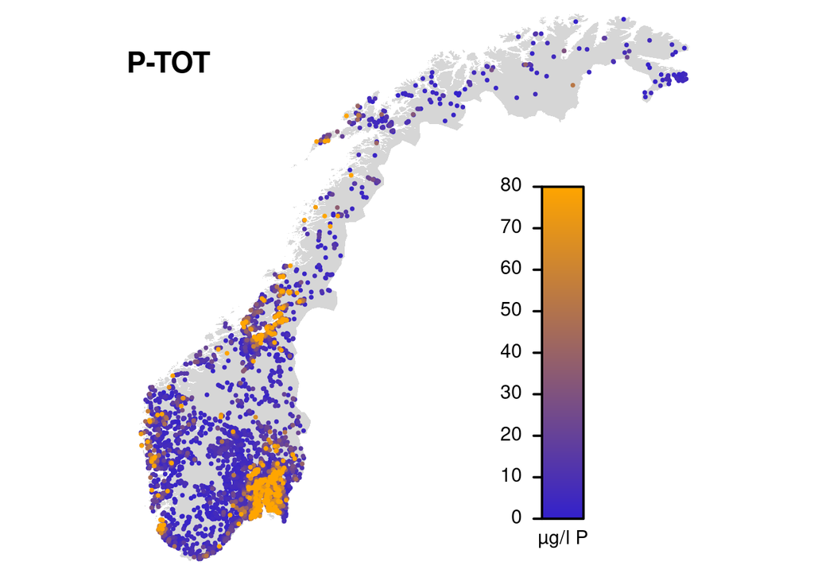

Map of Norway with points for all water bodies in which the indicator has been recorded. Colour indicates the average unscaled variable value for the water body.

```r
{
  xaxis <- seq(0, 80, 10)
  dig <- 0
  snudd <- TRUE

  ml <- V[which(V$id %in%
               VL$id[which(VL$lokid %in%
                         DATA$lokid[which(DATA$verdi %mellom% range(xaxis))])]), ]
  ml$maaling <- NA
  for (i in 1:nrow(ml)) {
    ml$maaling[i] <- mean(DATA$verdi[which(DATA$lokid %in%
                                             VL$lokid[which(VL$id == ml$id[i])])])
  }
  z <- 2
  fjern <- c()
  while (length(which(ml$maaling < xaxis[z])) == 0) {
    fjern <- c(fjern, z - 1)
    z <- z + 1
  }
  z <- length(xaxis) - 1
  while (length(which(ml$maaling > xaxis[z])) == 0) {
    fjern <- c(fjern, z + 1)
    z <- z - 1
  }
  if (length(fjern)) xaxis <- xaxis[-fjern]
  if (snudd) xaxis <- rev(xaxis)
  xlim <- range(xaxis)
  ml$maaling <- sapply(sapply(ml$maaling, max, xlim[1]), min, xlim[2])
  ml <- ml[order(ml$maaling, decreasing = !snudd), ]

  load("../data/Norge.map")
  par(mai = rep(0, 4))
  plot(Norge.kontur, xlim = c(3.5, 31.5), ylim = c(57.5, 71.5),
       xaxs = "i", yaxs = "i", asp = 2, col = grey(0.84), border = NA)
  points(ml$long, ml$lat, pch = 20, cex = 0.6, col = if (snudd)
         farve(ml$maaling, xlim[2], xlim[1]) else
         farve(ml$maaling, xlim[1], xlim[2]))
  text(6, 70, tittel, cex = 1.5, font = 2)
  for (i in seq(0, 0.999, 0.001)) {
    rect(24, 59+i*8, 26, 59+(i+0.001)*8, border = NA,
         col = if (snudd) farve(i, 1, 0) else farve(i, 0, 1))
  }
  rect(24, 59, 26, 67, lwd = 2)
  for (i in xaxis) {
    lines(c(24.0,23.6), rep(59 + 8 * (i-xlim[1]) / (xlim[2]-xlim[1]), 2), lwd=2)
  }
  text(23.6, 59 + 8 * (xaxis - xlim[1]) / (xlim[2] - xlim[1]),
       erstatt(formatC((xaxis), dig, format = "f"), "-", "−"), pos = 2)
  if (length(unique(DATA$enhet)) %=% 1 &
             unique(DATA$enhet) %!=% "3" & exists("Enheter")) {
    text(25, 58.5, Enheter[which(Enheter[, 1] == unique(DATA$enhet)), 2])
  }
}
```

### 9.2 Calculating mEQRs using reference levels

Following the description in section 3.5, measurements need to be transformed into mEQR values. Let us have closer look at the reference levels of the indicator (which are given in DGVF 2025).

```r
klassegrenser <- hentKlassegrenser("../data/klassegrenser_" %+% indikator %+% ".xlsx")
if (nrow(klassegrenser) > 1) {
  m <- matrix(0, 8, 2, dimnames = list(
    c("Pessimum:", "Range of X_" %+% seq(0, 100, 20) %+% ":", "Optimum:"),
    c("from", "to")))
  m[, 1] <- apply(klassegrenser, 2, min, na.rm = TRUE)
  m[, 2] <- apply(klassegrenser, 2, max, na.rm = TRUE)
  klassegrenser <- klassegrenser[which(!is.na(klassegrenser[, 1]))[1], ]
} else {
  m <- t(klassegrenser)
  dimnames(m) <- list(c("Pessim.", "X_0   =", "X_20  =", "X_40  =", "X_60  =",
                        "X_80  =", "X_100 =", "Optimum"), "")
}
print(m)
```

```
                from  to
Pessimum:        Inf Inf
Range of X_0:    Inf Inf
Range of X_20:    20  98
Range of X_40:    11  58
Range of X_60:     5  29
Range of X_80:     3  20
Range of X_100:    2  11
Optimum:           0   0
```

Since reference values differ between water body types, their ranges are shown above.

The following graph shows the scaling and transformation of the indicator (using the WFD colour coding for ecological status classes).

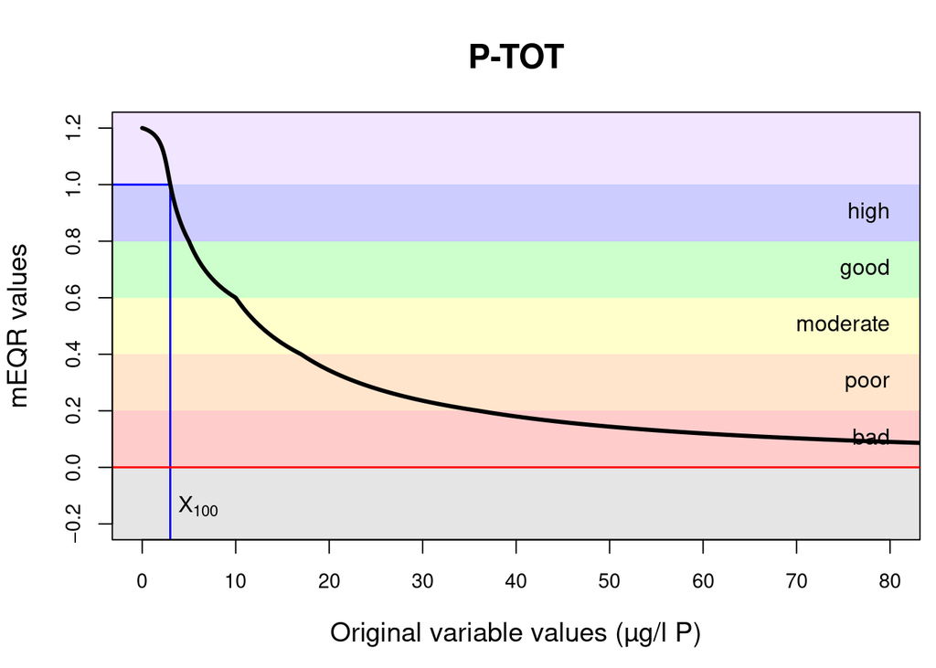

Scaling and transformation from variable measurements to mEQR values

```r
xlim <- c(0, 80)
xaxis <- seq(0, 80, 10)
yaxis <- seq(-0.2, 1.2, 0.2)
x <- seq(0, 100, le = 1000)
y <- mEQR(x, klassegrenser)
forklar <- "Original variable values"
if (unique(DATA$enhet) %!=% "3" & exists("Enheter")) {
  forklar <- forklar %+% " (" %+%
    Enheter[which(Enheter[, 1] == unique(DATA$enhet)), 2] %+% ")"
}
par(mai = c(0.96, 0.84, 0.84, 0.12))
plot(x, y, ty = "l", main = tittel,
     xlim = xlim,         xaxs = "r", xaxt = "n", xlab = forklar,
     ylim = c(-0.2, 1.2), yaxs = "r", yaxt = "n", ylab = "mEQR values",
     cex.main = 1.5, cex.lab = 1.2)
rect(xlim[1]-144,-0.4, xlim[2]+144, 0.0, col = rgb(0.0, 0.0, 0.0, 0.1), border = NA)
rect(xlim[1]-144, 0.0, xlim[2]+144, 0.2, col = rgb(1.0, 0.0, 0.0, 0.2), border = NA)
rect(xlim[1]-144, 0.2, xlim[2]+144, 0.4, col = rgb(1.0, 0.5, 0.0, 0.2), border = NA)
rect(xlim[1]-144, 0.4, xlim[2]+144, 0.6, col = rgb(1.0, 1.0, 0.0, 0.2), border = NA)
rect(xlim[1]-144, 0.6, xlim[2]+144, 0.8, col = rgb(0.0, 1.0, 0.0, 0.2), border = NA)
rect(xlim[1]-144, 0.8, xlim[2]+144, 1.0, col = rgb(0.0, 0.0, 1.0, 0.2), border = NA)
rect(xlim[1]-144, 1.0, xlim[2]+144, 1.4, col = rgb(0.5, 0.0, 1.0, 0.1), border = NA)
lines(c(xlim[1] - 144,    klassegrenser[7]), c(+1, 1), lwd = 1.5, col = "blue")
lines(c(klassegrenser[7], klassegrenser[7]), c(-1, 1), lwd = 1.5, col = "blue")
lines(c(xlim[1] - 144,    xlim[2] + 144),    c(+0, 0), lwd = 1.5, col = "red")
#lines(c(klassegrenser[2], klassegrenser[2]), c(-1, 0), lwd = 1.5, col = "red")
lines(x, y, lwd = 3)
axis(1, xaxis, erstatt(xaxis, "-", "−"), cex.axis = 0.9)
axis(2, yaxis, c("−0.2", "0.0", 0.2, 0.4, 0.6, 0.8, "1.0", 1.2), cex.axis = 0.9)
text(xlim[2], seq(0.1, 0.9, 0.2), c("bad", "poor", "moderate", "good", "high"),
     pos = 2, offset = 0)
rf <- klassegrenser[7] > klassegrenser[2]
text(klassegrenser[2], -0.15, expression(X[0]),   pos=ifelse(rf, 4, 2), offset=0.3)
text(klassegrenser[7], -0.15, expression(X[100]), pos=ifelse(rf, 2, 4), offset=0.3)
```

Note that variable values may be better (smaller) than X<sub>100</sub> (blue line). An asymptotic transformation is used for X < X<sub>100</sub> in order to keep mEQR values below 1.2. Note also that X<sub>0</sub> is infinite, a situation that is taken care of by using a hyperbolic scaling function.

### 9.3 Estimating the indicator values and their uncertainty

With the necessary files in place, the calculations can start. This is done using the function WFD2ECA (“Water Framework Directive to Ecosystem Condition Account”), which is [documented in the WFD2ECA repository](https://github.com/NINAnor/WFD2ECA/blob/main/forklar/dataflow.md) (Sandvik 2025).

The function produces summaries of the steps performed (for the time being, the information is provided in Norwegian only). It has to be run separately for each water category, i.e. for rivers (with `vannkategori = "R"`) and lakes (with `vannkategori = "L"`). Here, the code illustrates a run for (*a subset of*) river water bodies.

```r
utmating <- WFD2ECA(
  DATA = DATA,
  vannforekomster = V,
  vannlokaliteter = VL,
  parameter = indikator,
  vannkategori = "R",
  iterasjoner = 1000,
  SEED = 479001600,
  vis = FALSE
)
```

```
   Undersøkelse av innmatingsdata
   ==============================

Det foreligger 25000 målinger av parameteren P-TOT [Totalfosfor].

OBS: 734 målinger ble ekskludert fordi de ble tatt før 2010.

OBS: 337 målinger ble ekskludert fordi de ble tatt etter 2024.

OBS: 49 målinger ble ekskludert fordi de ikke kunne knyttes til noen kjent vannlokalitet.

OBS: 2755 målinger ble ekskludert fordi deres vannlokaliteter ikke kunne knyttes til noen
     typifisert vannforekomst.

OBS: 4988 målinger ble ekskludert fordi de ikke ble foretatt i en elvevannforekomst.

OBS: 4799 målinger ble ekskludert fordi de ble foretatt i en vanntype som parameteren
     ikke har definerte referanseverdier og klassegrenser i.

OBS: 3711 datapunkt måtte fjernes fra datasettet fordi de ikke oppfyller de spesifikke
     kravene som stilles til målinger av P-TOT.

OBS: For rapportåret 2012 foreligger bare målinger fra 12 vannforekomster. Det er
     dessverre for få, og denne rapportperioden må derfor utgå.

OBS: For rapportåret 2015 foreligger bare målinger fra 6 vannforekomster. Det er
     dessverre for få, og denne rapportperioden må derfor utgå.

OBS: For rapportåret 2018 foreligger bare målinger fra 19 vannforekomster. Det er
     dessverre for få, og denne rapportperioden må derfor utgå.

Dataene som inngår i modelltilpasninga, inneholder dermed
- 7219 målinger fra
- 343 vannlokaliteter i
- 269 vannforekomster i
- 19 fylker
- mellom 2019 og 2024.


   Skalering til mEQR-verdier
```

[output cut: 27 more lines]

```
   Ekstrapolering til ikke-målte vannforekomster
   =============================================

Det fins 23343 typifiserte elvevannforekomster.
Av disse har 21955 vannforekomster en vanntype som parameteren P-TOT er definert for.
112 vannforekomster er av typen "alkalitet = 5", som det ikke foreligger målinger av
P-TOT fra. Disse blir ekskludert fra ekstrapoleringa, slik at 21843 vannforekomster er
igjen.
Det foreligger altså målinger for 1 % av de relevante vannforekomstene (269 av 21843).


   Simulering
   ==========

P-TOTs mEQR-verdier har medianen 1,068 og strekker seg fra 0,750 til 1,157.
```

### 9.4 Summary of the output

The output is a list with one list element per geographic reporting level (i.e., in this case, one for the national and one for the regional level). For each geographical unit on this level and each reporting year, the predicted value and the simulated values are saved.

```r
{
  ut <- utmating
  attributes(ut) <- attributes(ut)[1:3]
  # to simplify the output, most attributes are removed
  str(ut)
  rm(ut)
}
```

```
List of 2
 $ Norge   : num [1, 1:2, 1:1001] 1.103 0.993 1.105 0.998 1.105 ...
  ..- attr(*, "dimnames")=List of 3
  .. ..$ rike        : chr "Norge"
  .. ..$ aar         : chr [1:2] "2021" "2024"
  .. ..$ simuleringer: chr [1:1001] "pred" "1" "2" "3" ...
 $ landsdel: num [1:5, 1:2, 1:1001] 0.861 1.064 1.098 1.151 1.153 ...
  ..- attr(*, "dimnames")=List of 3
  .. ..$ landsdel    : chr [1:5] "Østlandet" "Sørlandet" "Vestlandet" "Midt-Norge" ...
  .. ..$ aar         : chr [1:2] "2021" "2024"
  .. ..$ simuleringer: chr [1:1001] "pred" "1" "2" "3" ...
 - attr(*, "parameter")= chr "P-TOT"
 - attr(*, "vannkategori")= chr "R"
```

Note that the output consists of mEQR values, i.e. it may contain values below 0 or above 1. The values thus need to be truncated in a final step. They then correspond to nEQR values sensu WFD and indicator values sensu SEEA EA.

```r
{
cat("Range of values prior to truncation (mEQR): " %+%
    format(round(min(utmating$landsdel, na.rm=TRUE), 4), nsm=4, sci=FALSE) %+%
    " to " %+%
    format(round(max(utmating$landsdel, na.rm=TRUE), 4), nsm=4, sci=FALSE) %+% "\n")
tomrom <- ifelse(nchar(format(round(min(utmating$landsdel, na.rm=TRUE), 4),
                              nsm=4, sci=FALSE)) %=% 7, " ", "")
utmating <- trunker(utmating)
cat("Range of values _after_  truncation (nEQR): " %+% tomrom %+%
    format(round(min(utmating$landsdel, na.rm=TRUE), 4), nsm=4, sci=FALSE) %+%
    " to " %+%
    format(round(max(utmating$landsdel, na.rm=TRUE), 4), nsm=4, sci=FALSE) %+% "\n")
}
```

```
Range of values prior to truncation (mEQR): 0.7504 to 1.1567
Range of values _after_  truncation (nEQR): 0.7504 to 1.0000
```

The estimates and their confidence intervals may be summarised as tables.

```r
{
  kvantiler <- c(0.025, 0.25, 0.5, 0.75, 0.975)
  print(round(t(apply(utmating$Norge[  "Norge", , -1], 1, quantile, kvantiler)), 4))
  print(round(t(apply(utmating$landsdel[, "2024", -1], 1, quantile, kvantiler)), 4))
}
```

```
aar      2.5%    25%    50%    75%  97.5%
  2021 1.0000 1.0000 1.0000 1.0000 1.0000
  2024 0.9883 0.9917 0.9934 0.9952 0.9988

landsdel       2.5%    25%    50%    75%  97.5%
  Østlandet  0.7579 0.7692 0.7752 0.7820 0.7927
  Sørlandet  0.8622 0.8732 0.8789 0.8848 0.8947
  Vestlandet 0.9608 0.9706 0.9751 0.9798 0.9886
  Midt-Norge 1.0000 1.0000 1.0000 1.0000 1.0000
  Nord-Norge 1.0000 1.0000 1.0000 1.0000 1.0000
```

## 10. Results

As reference values of total phosphorus differ between water body types and the scaling function used is non-linear, aggregated averages of *unscaled* values (*variable* values sensu SEEA EA) are not informative. Therefore, this indicator is reported in terms of *scaled* values only (nEQR sensu WFD; *indicator* values sensu SEEA EA).

The results are here tabulated (a) for the whole country and different years, and (b) for regions in 2024. These estimates are based on all available data and 10,000 iterations and therefore differ from the ones above.

*NB: Please note that these results are not the final ones for 2024. The deadline for reporting WFD measurements taken in 2024 is September 2025, meaning that the values for 2024 are so far based mainly on measurements taken in 2022 and 2023.*

Indicator values for total phosphorus in rivers and lakes for Norway in different years

| Ecosystem | Year | Best estimate | Lower quartile | Upper quartile |
| --- | --- | --- | --- | --- |
| **Rivers** | 2024 | 0.925 | 0.922 | 0.928 |
| **Rivers** | 2021 | 0.945 | 0.943 | 0.948 |
| **Rivers** | 2018 | 0.939 | 0.936 | 0.942 |
| **Lakes** | 2024 | 0.876 | 0.872 | 0.881 |
| **Lakes** | 2021 | 0.924 | 0.920 | 0.928 |

Indicator values for total phosphorus in rivers and lakes for regions of Norway in 2024

| Ecosystem | Region | Best estimate | Lower quartile | Upper quartile |
| --- | --- | --- | --- | --- |
| **Rivers** | Østlandet | 0.881 | 0.875 | 0.886 |
| **Rivers** | Sørlandet | 0.907 | 0.900 | 0.913 |
| **Rivers** | Vestlandet | 0.989 | 0.983 | 0.994 |
| **Rivers** | Midt-Norge | 0.887 | 0.880 | 0.895 |
| **Rivers** | Nord-Norge | 0.945 | 0.941 | 0.950 |
| **Lakes** | Østlandet | 0.875 | 0.866 | 0.883 |
| **Lakes** | Sørlandet | 0.994 | 0.988 | 1.000 |
| **Lakes** | Vestlandet | 0.728 | 0.718 | 0.737 |
| **Lakes** | Midt-Norge | 0.860 | 0.848 | 0.872 |
| **Lakes** | Nord-Norge | 0.877 | 0.867 | 0.886 |